# CKME 136 - Laptimes at the Nurburgring

Samuel Tang

16/07/2020

Importing the data. Please note, to run the code, you must adjust wd accordingly. The data that is on GitHub is more than just this basic .csv file.

```r
getwd()
```

```
## [1] "C:/Users/Samuel Tang/Desktop/CKME 136/Code"
```

```r
setwd("C:\\Users\\Samuel Tang\\Desktop\\CKME 136\\Dataset")
cleandata <- read.csv("lap_times (edited).csv")
```

Exploring the data.

```r
str(cleandata)
```

```
## 'data.frame':    81 obs. of  18 variables:
##  $ Position           : int  1 2 3 4 5 6 7 8 9 10 ...
##  $ Year               : int  2013 2015 2015 2010 2012 2010 2013 2012 2015 2011 ...
##  $ Make               : chr  "Porsche" "Lamborghini" "Nissan" "Dodge" ...
##  $ Model              : chr  "918 Spyder" "Aventador LP 750-4 Superveloce" "GT-R Nismo" "Viper SRT-10 ACR" ...
##  $ Time               : chr  "06:57.0" "06:59.7" "07:08.7" "07:12.1" ...
##  $ Weight             : int  1634 1769 1720 1546 1480 1368 1740 1530 1548 1420 ...
##  $ Turbocharger       : int  0 0 1 0 0 1 1 0 1 0 ...
##  $ Supercharger       : int  0 0 0 0 0 0 0 1 0 1 ...
##  $ Hybrid             : int  1 0 0 0 0 0 0 0 0 0 ...
##  $ Powertrain         : chr  "V8" "V12" "V6" "V10" ...
##  $ Engine_Layout      : chr  "Mid-Engine" "Mid-Engine" "Front-Engine" "Front-Engine" ...
##  $ Horsepower         : int  875 740 591 600 563 612 545 638 661 505 ...
##  $ Torque             : int  944 509 481 560 354 516 463 604 561 470 ...
##  $ Drivetrain         : chr  "AWD" "AWD" "AWD" "RWD" ...
##  $ Body_Style         : chr  "Coupe" "Coupe" "Coupe" "Coupe" ...
##  $ Manual_Transmission: int  0 0 0 1 0 1 0 1 0 1 ...
##  $ KGperHP            : num  1.87 2.39 2.91 2.58 2.63 ...
##  $ Cylinders          : int  8 12 6 10 10 6 6 8 8 8 ...
```

```r
head(cleandata)
```

```
##   Position Year        Make                          Model    Time Weight
## 1        1 2013     Porsche                     918 Spyder 06:57.0   1634
## 2        2 2015 Lamborghini Aventador LP 750-4 Superveloce 06:59.7   1769
## 3        3 2015      Nissan                     GT-R Nismo 07:08.7   1720
## 4        4 2010       Dodge               Viper SRT-10 ACR 07:12.1   1546
## 5        5 2012       Lexus        LFA Nurburgring Package 07:14.6   1480
## 6        6 2010     Porsche                     911 GT2 RS 07:18.0   1368
##   Turbocharger Supercharger Hybrid Powertrain Engine_Layout Horsepower Torque
## 1            0            0      1         V8    Mid-Engine        875    944
## 2            0            0      0        V12    Mid-Engine        740    509
## 3            1            0      0         V6  Front-Engine        591    481
## 4            0            0      0        V10  Front-Engine        600    560
## 5            0            0      0        V10  Front-Engine        563    354
## 6            1            0      0     Flat 6   Rear-Engine        612    516
##   Drivetrain Body_Style Manual_Transmission  KGperHP Cylinders
## 1        AWD      Coupe                   0 1.867429         8
## 2        AWD      Coupe                   0 2.390541        12
## 3        AWD      Coupe                   0 2.910321         6
## 4        RWD      Coupe                   1 2.576667        10
## 5        RWD      Coupe                   0 2.628774        10
## 6        RWD      Coupe                   1 2.235294         6
```

```r
tail(cleandata)
```

```
##    Position Year      Make          Model    Time Weight Turbocharger
## 76       76 2011       BMW             M5 07:55.0   1870            1
## 77       77 2000   Porsche      911 Turbo 07:56.0   1540            1
## 78       78 2003   Ferrari         360 CS 07:56.0   1430            0
## 79       79 2009   Ferrari  California GT 07:56.0   1870            0
## 80       80 2009   Porsche Panamera Turbo 07:56.0   1870            1
## 81       81 2002 Chevrolet   Corvette Z06 07:56.0   1414            0
##    Supercharger Hybrid Powertrain Engine_Layout Horsepower Torque Drivetrain
## 76            0      0         V8  Front-Engine        552    502        RWD
## 77            0      0     Flat 6   Rear-Engine        414    413        AWD
## 78            0      0         V8    Mid-Engine        419    275        RWD
## 79            0      0         V8  Front-Engine        453    358        RWD
## 80            0      0         V8  Front-Engine        493    516        AWD
## 81            0      0         V8  Front-Engine        405    398        RWD
##    Body_Style Manual_Transmission  KGperHP Cylinders
## 76      Sedan                   0 3.387681         8
## 77      Coupe                   1 3.719807         6
## 78      Coupe                   0 3.412888         8
## 79      Coupe                   0 4.128035         8
## 80      Sedan                   0 3.793103         8
## 81      Coupe                   1 3.491358         8
```

```r
nrow(cleandata)
```

```
## [1] 81
```

```r
ncol(cleandata)
```

```
## [1] 18
```

In order to better analyze the data, Time was converted into an easier, more comparable, measure (seconds).

```r
library(lubridate)
cleandata$Mins2Secs <- period_to_seconds(ms(cleandata$Time))
```

Below is a basic summary and visualization of all the numeric variables, plotted against time (Mins2Secs). Mins2Secs (which is time,) is our dependent variable. As expected, there are some weak and some strong relationships.

Comments on each of the variables are noted below in the code. In summary, Year, Weight, Horsepower, Torque, KGperHP, and Cylinders all appear to have a relationship with Time. The other variables have no explicit or obvious relationship with Time.

```r
summary(cleandata)
```

```
##     Position       Year          Make              Model
##  Min.   : 1   Min.   :1992   Length:81          Length:81
##  1st Qu.:21   1st Qu.:2005   Class :character   Class :character
##  Median :41   Median :2009   Mode  :character   Mode  :character
##  Mean   :41   Mean   :2009
##  3rd Qu.:61   3rd Qu.:2011
##  Max.   :81   Max.   :2017
##      Time               Weight      Turbocharger    Supercharger
##  Length:81          Min.   :1230   Min.   :0.000   Min.   :0.0000
##  Class :character   1st Qu.:1420   1st Qu.:0.000   1st Qu.:0.0000
##  Mode  :character   Median :1548   Median :0.000   Median :0.0000
##                     Mean   :1575   Mean   :0.321   Mean   :0.1235
##                     3rd Qu.:1720   3rd Qu.:1.000   3rd Qu.:0.0000
##                     Max.   :2058   Max.   :1.000   Max.   :1.0000
##      Hybrid         Powertrain        Engine_Layout        Horsepower
##  Min.   :0.00000   Length:81          Length:81          Min.   :227.0
##  1st Qu.:0.00000   Class :character   Class :character   1st Qu.:483.0
##  Median :0.00000   Mode  :character   Mode  :character   Median :542.0
##  Mean   :0.02469                                         Mean   :536.7
##  3rd Qu.:0.00000                                         3rd Qu.:600.0
##  Max.   :1.00000                                         Max.   :875.0
##      Torque     Drivetrain         Body_Style        Manual_Transmission
##  Min.   :258   Length:81          Length:81          Min.   :0.0000
##  1st Qu.:391   Class :character   Class :character   1st Qu.:0.0000
##  Median :463   Mode  :character   Mode  :character   Median :0.0000
##  Mean   :458                                         Mean   :0.3704
##  3rd Qu.:509                                         3rd Qu.:1.0000
##  Max.   :944                                         Max.   :1.0000
##     KGperHP        Cylinders        Mins2Secs
##  Min.   :1.784   Min.   : 4.000   Min.   :417.0
##  1st Qu.:2.686   1st Qu.: 6.000   1st Qu.:448.0
##  Median :2.931   Median : 8.000   Median :459.0
##  Mean   :3.051   Mean   : 8.148   Mean   :457.7
##  3rd Qu.:3.423   3rd Qu.:10.000   3rd Qu.:469.2
##  Max.   :6.167   Max.   :12.000   Max.   :476.0
```

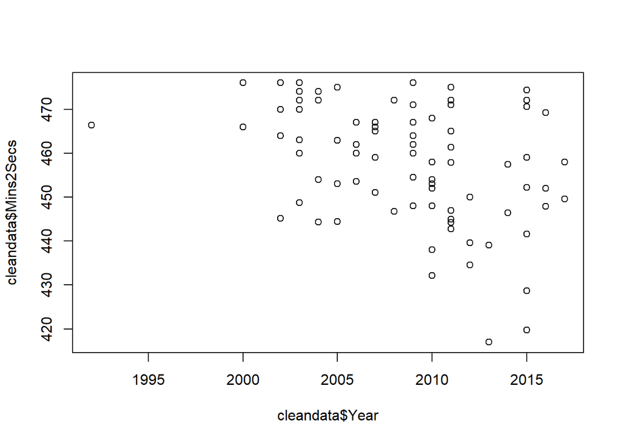

```r
plot(cleandata$Year, cleandata$Mins2Secs) #negative relationship, represents other technological improvements, difficult to dissect
```

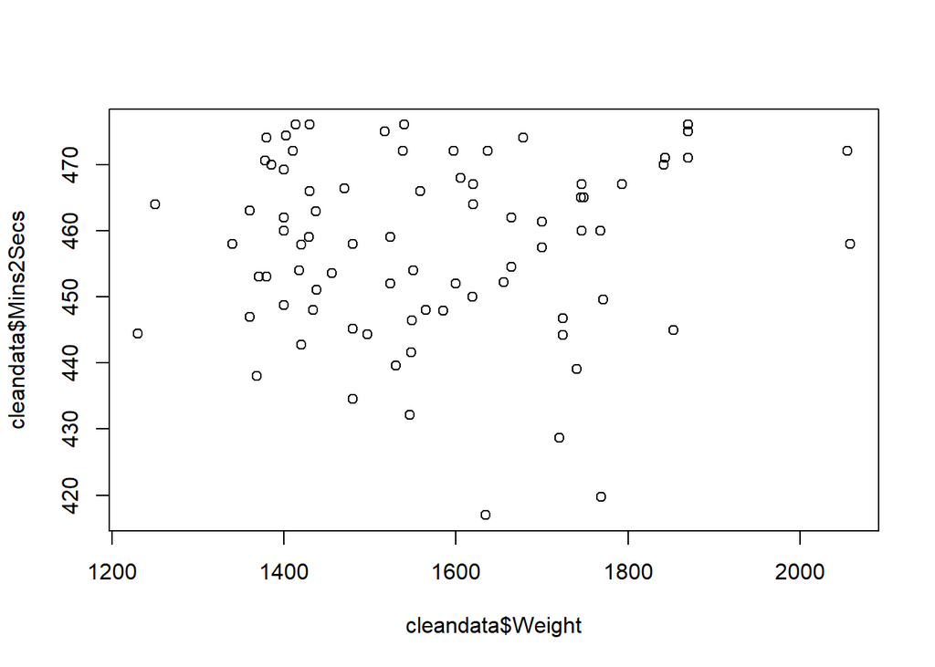

```r
plot(cleandata$Weight, cleandata$Mins2Secs) #weak positive relationship - Maybe important for clusters? May be useful to group into different segments
```

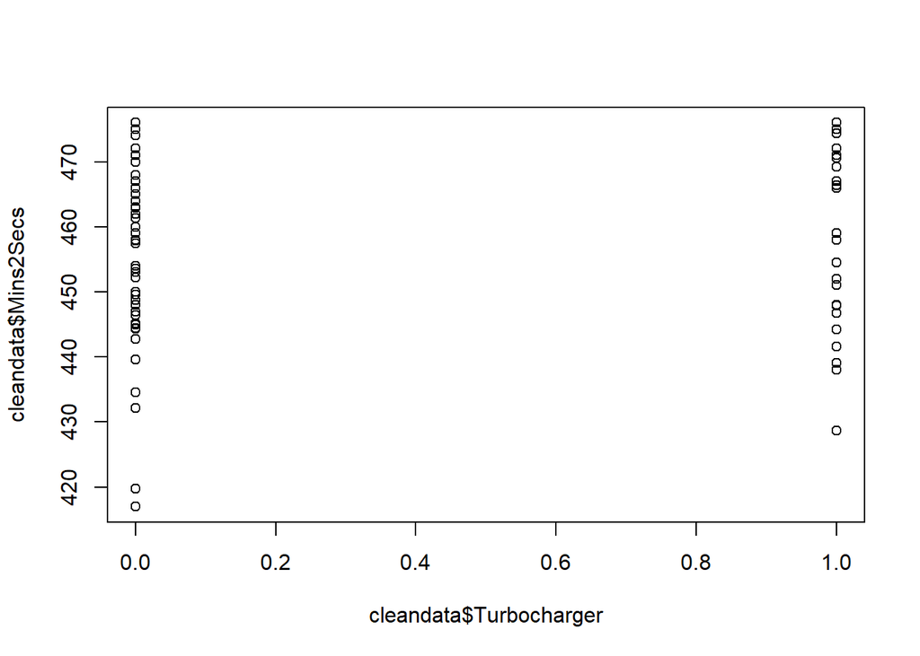

```r
plot(cleandata$Turbocharger, cleandata$Mins2Secs) #no clear relationship - must compare the three engine augmentation styles, Turbo, Super, Hybrid (Position, Time, Weight, HP, Torque)
```

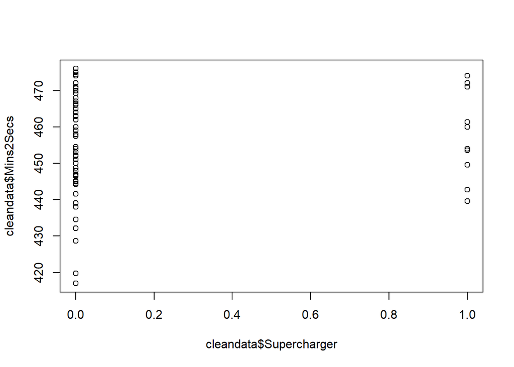

```r
plot(cleandata$Supercharger, cleandata$Mins2Secs) #no clear relationship - must compare the three engine augmentation styles, Turbo, Super, Hybrid (Position, Time, Weight, HP, Torque)
```

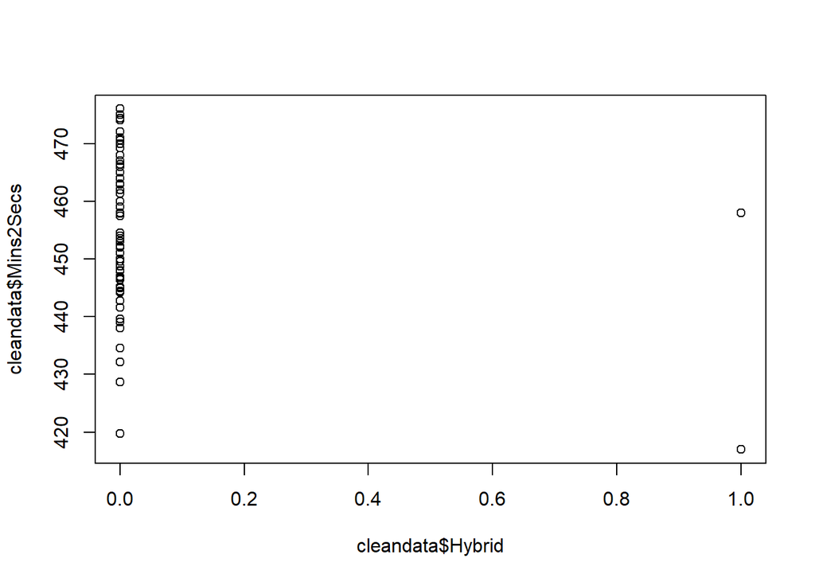

```r
plot(cleandata$Hybrid, cleandata$Mins2Secs) #no clear relationship, only two examples - Need to explain advantages (torque+HP > weight?, prove by kg/hp?)
```

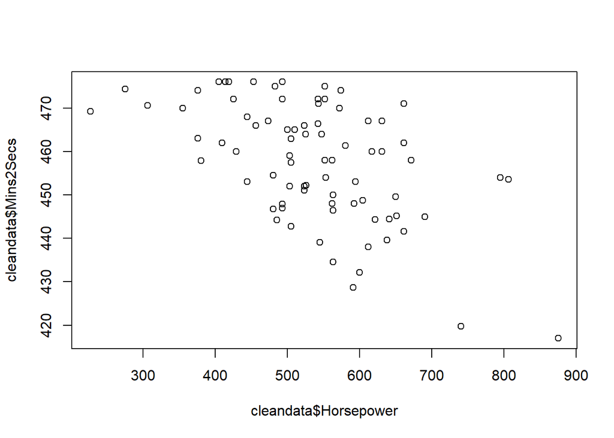

```r
plot(cleandata$Horsepower, cleandata$Mins2Secs) #weak negative trend - why is it not as obvious/strong?
```

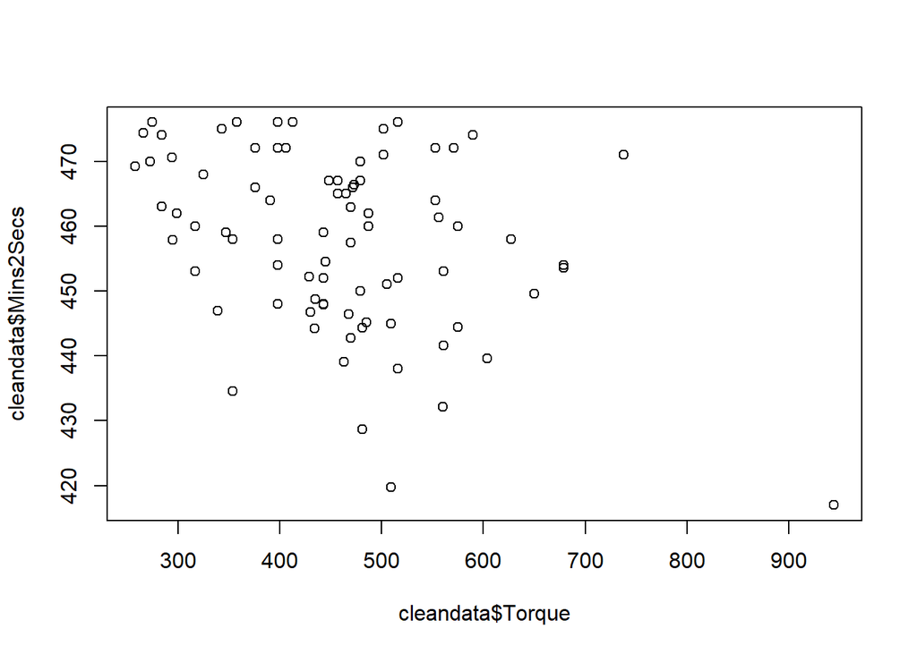

```r
plot(cleandata$Torque, cleandata$Mins2Secs) #weak negative trend - why is it not as obvious/strong?
```

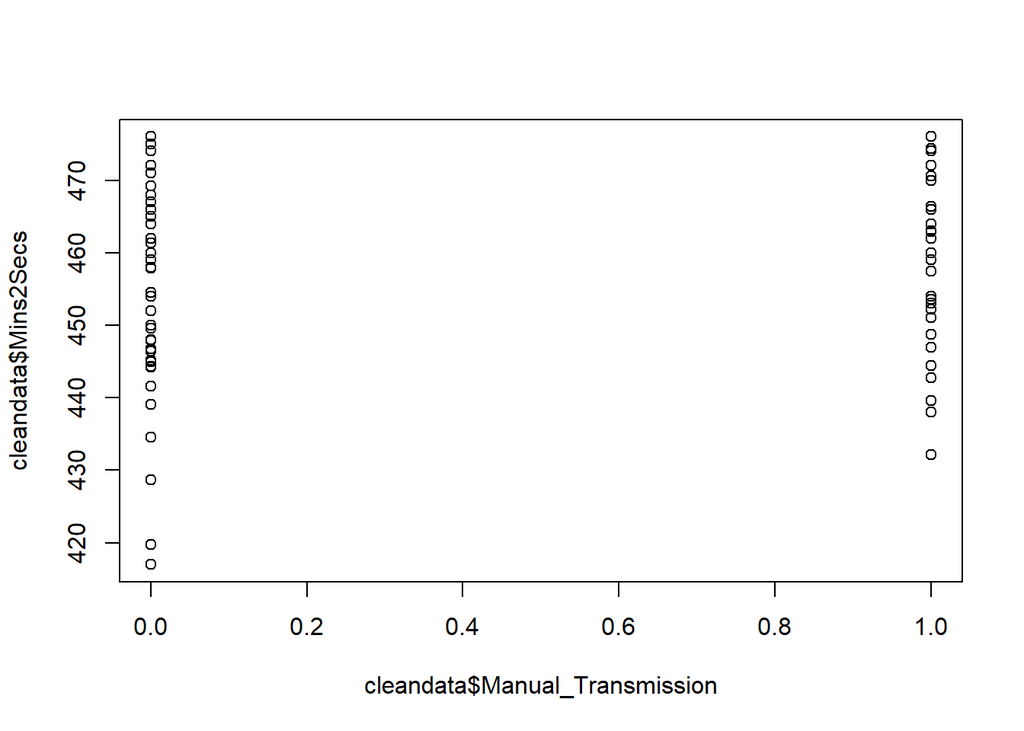

```r
plot(cleandata$Manual_Transmission, cleandata$Mins2Secs) #Manual transmission may increase time, investigate averages for groups
```

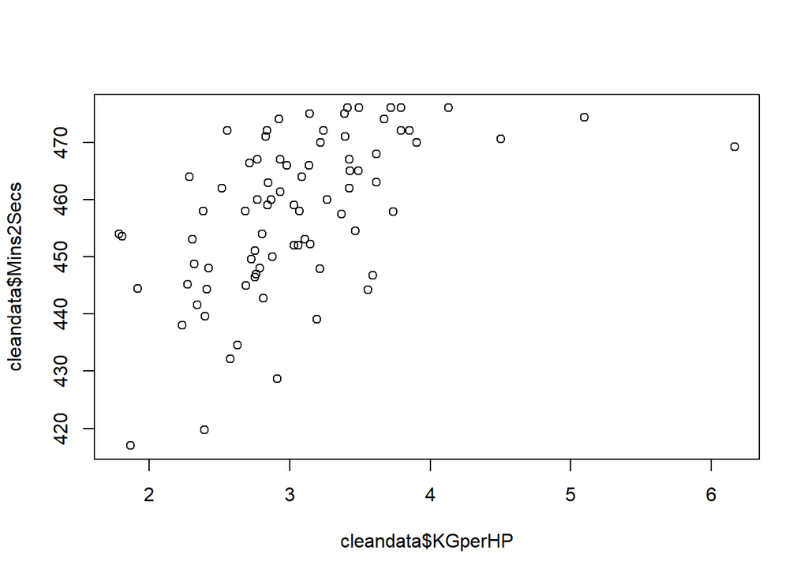

```r
plot(cleandata$KGperHP, cleandata$Mins2Secs) #Positive trend, resembles a logarithmic function
```

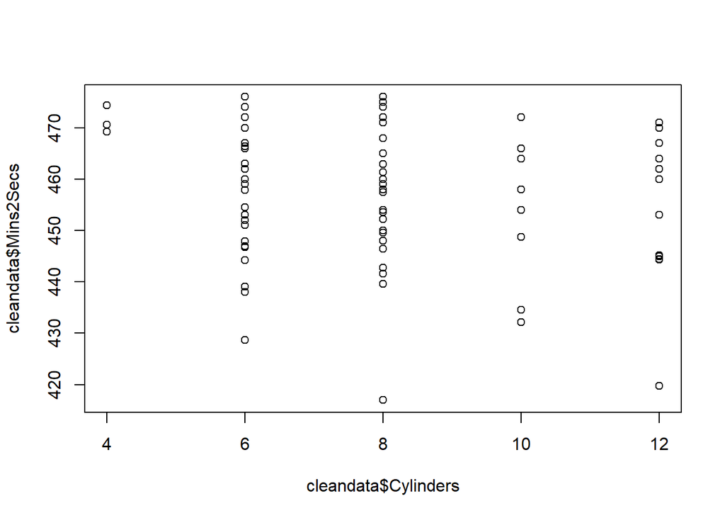

```r
plot(cleandata$Cylinders, cleandata$Mins2Secs) #Weak negative trend, investigate averages for each group (this is a derivative of powertrain)
```

Categorical variables were created to represent different examples of “Drivetrain” and “Engine_Layout”. Namely: AWD,RWD,FWD,MidEngine, FrontEngine, RearEngine. All will be represented for the time being, and one shall be removed later to avoid the Dummy-variable trap.

The converted variables as well as all other numeric attributes will be subset to a new dataframe for further analysis.

```r
cleandata$AWD = 0
cleandata$AWD[which(grepl("AWD", cleandata$Drivetrain))] = 1
cleandata$RWD = 0
cleandata$RWD[which(grepl("RWD", cleandata$Drivetrain))] = 1
cleandata$FWD = 0
cleandata$FWD[which(grepl("FWD", cleandata$Drivetrain))] = 1
cleandata$MidEngine = 0
cleandata$MidEngine[which(grepl("Mid-Engine", cleandata$Engine_Layout))] = 1
cleandata$RearEngine = 0
cleandata$RearEngine[which(grepl("Rear-Engine", cleandata$Engine_Layout))] = 1
cleandata$FrontEngine = 0
cleandata$FrontEngine[which(grepl("Front-Engine", cleandata$Engine_Layout))] = 1

allnumeric <- cleandata[,c(1,2,6:9,12,13,16:25)]
```

It is hard to visualize if there is a relationship between the categorical variables; a Chi-Square Test will be performed to see if there are any statistical differences among the factors, when put against Mins2Secs (Time).

Although not conclusive, it appears that Year, Cylinders, and Drivetrain somewhat affect Mins2Secs. We can explore those differences further below.

```r
chisq.test(cleandata$Year, cleandata$Mins2Secs)
```

```
##
##  Pearson's Chi-squared test
##
## data:  cleandata$Year and cleandata$Mins2Secs
## X-squared = 951.68, df = 901, p-value = 0.1174
```

```r
chisq.test(cleandata$Manual_Transmission, cleandata$Mins2Secs)
```

```
##
##  Pearson's Chi-squared test
##
## data:  cleandata$Manual_Transmission and cleandata$Mins2Secs
## X-squared = 56.7, df = 53, p-value = 0.3388
```

```r
chisq.test(cleandata$Turbocharger, cleandata$Mins2Secs)
```

```
##
##  Pearson's Chi-squared test
##
## data:  cleandata$Turbocharger and cleandata$Mins2Secs
## X-squared = 52.401, df = 53, p-value = 0.4974
```

```r
chisq.test(cleandata$Supercharger, cleandata$Mins2Secs)
```

```
##
##  Pearson's Chi-squared test
##
## data:  cleandata$Supercharger and cleandata$Mins2Secs
## X-squared = 53.585, df = 53, p-value = 0.4517
```

```r
chisq.test(cleandata$Hybrid, cleandata$Mins2Secs)
```

```
##
##  Pearson's Chi-squared test
##
## data:  cleandata$Hybrid and cleandata$Mins2Secs
## X-squared = 53.316, df = 53, p-value = 0.462
```

```r
chisq.test(cleandata$Cylinders, cleandata$Mins2Secs)
```

```
##
##  Pearson's Chi-squared test
##
## data:  cleandata$Cylinders and cleandata$Mins2Secs
## X-squared = 238.88, df = 212, p-value = 0.09918
```

```r
chisq.test(cleandata$Drivetrain, cleandata$Mins2Secs)
```

```
##
##  Pearson's Chi-squared test
##
## data:  cleandata$Drivetrain and cleandata$Mins2Secs
## X-squared = 125.04, df = 106, p-value = 0.09994
```

```r
chisq.test(cleandata$Engine_Layout, cleandata$Mins2Secs)
```

```
##
##  Pearson's Chi-squared test
##
## data:  cleandata$Engine_Layout and cleandata$Mins2Secs
## X-squared = 99.248, df = 106, p-value = 0.6656
```

Correlation analysis was performed using the Spearman method as the variables were not normally distributed.

According to chart, the p-values indicate Hybrid(*), Horsepower(*), Torque(*), KGperHP(*), Cylinders(*), AWD(*), FWD(*), and MidEngine(*) are significantly correlated to Time (Mins2Secs).

Another purpose is to check if any variables are highly correlated with one another, this will help to combat multicollinearity.

```r
cormatrix  <- cor(allnumeric)
#install.packages("PerformanceAnalytics")
library(PerformanceAnalytics)
```

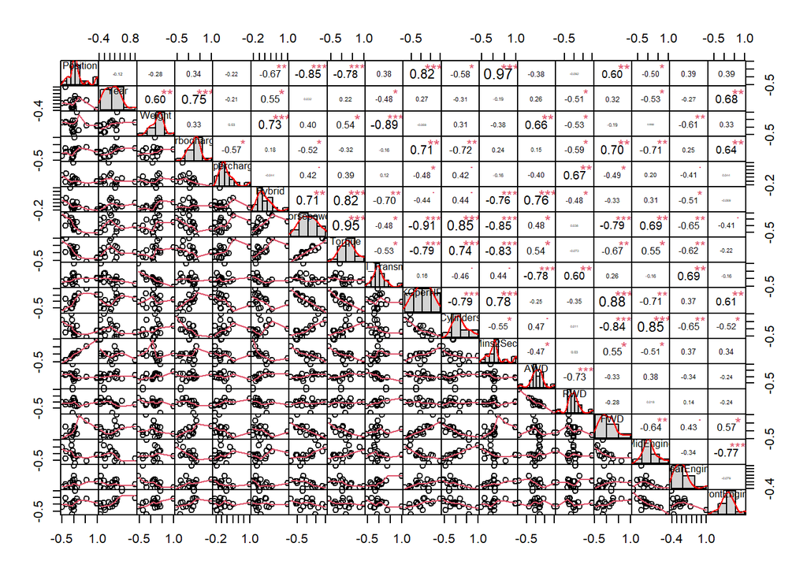

```r
chart.Correlation(cormatrix, method = "spearman")
```

Other Feature-Selection Techniques were performed for dimensionality reduction purposes. Three tests are here employed (MLR, Stepwise, Boruta) below, more can be done later.

The general consensus is that Year, Weight (or KGperHP), Horsepower (or KGperHP), Cylinders, and MidEngine are the most valuable indicators.

```r
#FEATURING ALL VARIABLES, INCLUDING Horsepower, Weight, KGperHP
#---Basic Multiple Linear Regression---
alltimeMLR <- lm(Mins2Secs~Year+Weight+Turbocharger+Supercharger+Hybrid+Horsepower+Torque+Manual_Transmission+KGperHP+Cylinders+AWD+RWD+FWD+MidEngine+RearEngine+FrontEngine, allnumeric)
summary(alltimeMLR) #Year(**), Weight(*), Supercharger(*), Horsepower(**), Cylinders(.), MidEngine(*)
```

```
##
## Call:
## lm(formula = Mins2Secs ~ Year + Weight + Turbocharger + Supercharger +
##     Hybrid + Horsepower + Torque + Manual_Transmission + KGperHP +
##     Cylinders + AWD + RWD + FWD + MidEngine + RearEngine + FrontEngine,
##     data = allnumeric)
##
## Residuals:
##     Min      1Q  Median      3Q     Max
## -17.880  -5.284  -0.004   4.599  20.736
##
## Coefficients: (2 not defined because of singularities)
##                       Estimate Std. Error t value Pr(>|t|)
## (Intercept)         2360.51395  585.61281   4.031 0.000146 ***
## Year                  -0.95327    0.28798  -3.310 0.001514 **
## Weight                 0.03637    0.01476   2.464 0.016346 *
## Turbocharger           3.37465    3.68973   0.915 0.363728
## Supercharger          10.72954    4.57941   2.343 0.022153 *
## Hybrid                 6.90917    8.49382   0.813 0.418894
## Horsepower            -0.13633    0.04432  -3.076 0.003049 **
## Torque                 0.01717    0.02197   0.782 0.437188
## Manual_Transmission   -0.36748    2.78288  -0.132 0.895346
## KGperHP                0.52974    7.00310   0.076 0.939931
## Cylinders              1.87064    0.97222   1.924 0.058657 .
## AWD                   -6.58124   11.60627  -0.567 0.572609
## RWD                   -1.29355   11.38899  -0.114 0.909917
## FWD                         NA         NA      NA       NA
## MidEngine              8.56830    3.71479   2.307 0.024229 *
## RearEngine             2.87301    3.62230   0.793 0.430535
## FrontEngine                 NA         NA      NA       NA
## ---
## Signif. codes:  0 '***' 0.001 '**' 0.01 '*' 0.05 '.' 0.1 ' ' 1
##
## Residual standard error: 8.516 on 66 degrees of freedom
## Multiple R-squared:  0.6716, Adjusted R-squared:  0.602
## F-statistic: 9.642 on 14 and 66 DF,  p-value: 3.592e-11
```

```r
#---Stepwise Regression---
#install.packages("olsrr")
library("olsrr")
stepwisetime <- ols_step_both_p(alltimeMLR)
stepwisetime #Horsepower, Year, Weight, Supercharger, MidEngine, AWD
```

```
##
##                                 Stepwise Selection Summary
## ------------------------------------------------------------------------------------------
##                          Added/                   Adj.
## Step      Variable      Removed     R-Square    R-Square     C(p)        AIC        RMSE
## ------------------------------------------------------------------------------------------
##    1     Horsepower     addition       0.294       0.285    64.8380    628.2376    11.4105
##    2        Year        addition       0.424       0.409    40.7700    613.7877    10.3746
##    3       Weight       addition       0.562       0.545    15.0190    593.5897     9.1047
##    4    Supercharger    addition       0.587       0.565    11.9970    590.8316     8.8991
##    5     MidEngine      addition       0.624       0.599     6.5700    585.2379     8.5480
##    6        AWD         addition       0.640       0.611     5.3550    583.7162     8.4205
## ------------------------------------------------------------------------------------------
```

```r
#---Boruta---
#install.packages("Boruta")
library(Boruta)
Borutatime <- Boruta(Mins2Secs~Year+Weight+Turbocharger+Supercharger+Hybrid+Horsepower+Torque+Manual_Transmission+KGperHP+Cylinders+AWD+RWD+FWD+MidEngine+RearEngine+FrontEngine, allnumeric)
boruta_signif <- getSelectedAttributes(Borutatime, withTentative = TRUE)
print(boruta_signif) #Results were that Year, Weight, Horsepower, Torque, KGperHP, Cylinders, FWD, and MidEngine were significant to time
```

```
## [1] "Year"       "Weight"     "Horsepower" "Torque"     "KGperHP"
## [6] "Cylinders"  "FWD"        "MidEngine"
```

```r
#FEATURING Horsepower and Weight, BUT NOT INCLUDING KGperHP (This is to combat multicollinearity)
#---Basic Multiple Linear Regression---
mosttimeMLR <- lm(Mins2Secs~Year+Weight+Turbocharger+Supercharger+Hybrid+Horsepower+Torque+Manual_Transmission+Cylinders+AWD+RWD+FWD+MidEngine+RearEngine+FrontEngine, allnumeric)
summary(mosttimeMLR) #Year(**), Weight(***), Supercharger(*), Horsepower(***), Cylinders(*), MidEngine(*)
```

```
##
## Call:
## lm(formula = Mins2Secs ~ Year + Weight + Turbocharger + Supercharger +
##     Hybrid + Horsepower + Torque + Manual_Transmission + Cylinders +
##     AWD + RWD + FWD + MidEngine + RearEngine + FrontEngine, data = allnumeric)
##
## Residuals:
##     Min      1Q  Median      3Q     Max
## -17.788  -5.223  -0.012   4.590  20.686
##
## Coefficients: (2 not defined because of singularities)
##                       Estimate Std. Error t value Pr(>|t|)
## (Intercept)          2.368e+03  5.722e+02   4.139 9.97e-05 ***
## Year                -9.559e-01  2.837e-01  -3.370  0.00125 **
## Weight               3.726e-02  8.946e-03   4.165 9.11e-05 ***
## Turbocharger         3.303e+00  3.540e+00   0.933  0.35413
## Supercharger         1.069e+01  4.516e+00   2.367  0.02081 *
## Hybrid               6.941e+00  8.420e+00   0.824  0.41268
## Horsepower          -1.391e-01  2.478e-02  -5.614 4.10e-07 ***
## Torque               1.748e-02  2.142e-02   0.816  0.41736
## Manual_Transmission -4.054e-01  2.717e+00  -0.149  0.88184
## Cylinders            1.850e+00  9.264e-01   1.997  0.04988 *
## AWD                 -7.243e+00  7.574e+00  -0.956  0.34239
## RWD                 -1.961e+00  7.143e+00  -0.275  0.78450
## FWD                         NA         NA      NA       NA
## MidEngine            8.586e+00  3.680e+00   2.333  0.02266 *
## RearEngine           2.884e+00  3.592e+00   0.803  0.42486
## FrontEngine                 NA         NA      NA       NA
## ---
## Signif. codes:  0 '***' 0.001 '**' 0.01 '*' 0.05 '.' 0.1 ' ' 1
##
## Residual standard error: 8.452 on 67 degrees of freedom
## Multiple R-squared:  0.6716, Adjusted R-squared:  0.6079
## F-statistic: 10.54 on 13 and 67 DF,  p-value: 1.075e-11
```